# Variable Transformation

Variables contained in a dataset seldom come in an analysis-ready format. Certain variables may need to be transformed before they can be used for predictive analysis. The nature and types of transformation depend on whether the variable is categorical or numeric. We will first examine transformations for categorical variables before moving on to numeric variables.

# Categorical Variables

A variable containing a set of discrete levels is said to be categorical. Other labels used to characterize this type of data include qualitative variable, non-metric variable and discrete variable. Given below are some examples of categorical variables.

```r
cat_demo =
  data.frame(gender = sample(c('Male','Female'),size = 10,T),
           age_group = sample( c('18-29','30-39','40-49','50-59','60 or over'),size = 10,T),
           marital_status = sample(c('married','widowed','divorced','separated','never married'),size = 10,T),
           ethnicity = sample(c('White','Black or African American','Native American','Asian','Hispanic','Other'),size = 10,T),
           zip_code = factor(sample(10001:10055,10,T)))
cat_demo
```

| gender | age_group | marital_status | ethnicity | zip_code |
| --- | --- | --- | --- | --- |
| Male | 30-39 | married | Other | 10002 |
| Male | 18-29 | separated | Hispanic | 10035 |
| Male | 50-59 | widowed | Hispanic | 10047 |
| Female | 50-59 | divorced | Other | 10050 |
| Male | 50-59 | widowed | Asian | 10023 |
| Female | 40-49 | married | Black or African American | 10021 |
| Male | 30-39 | divorced | White | 10018 |
| Female | 30-39 | separated | Asian | 10016 |
| Female | 50-59 | never married | Native American | 10054 |
| Female | 40-49 | divorced | Other | 10039 |

Note the following characteristics of the variables:  
1. gender takes on two non-numeric values  
2. age_group has five age categories that are ordered. The values of age are in character form  
3. marital status has five non-numeric values. These values would not be expected to have an order  
4. ethnicity has six non-numeric values that are unordered  
5. zip_code has numeric values but the numbers are no more than identifiers of an area

With categorical variables, it is not possible to perform standard operations such as mean and standard deviation in general and barring a few exceptions (such as Tree and Tree-based models) cannot be used in their native form in a predictive model.

### Data

To illustrate techniques for variable transformation, we will make use of some [survey](https://pace.az1.qualtrics.com/jfe/form/SV_eMa9dFv46RYhqe1) data gathered by a marketing researcher interested in examining the relationship between health consciousness and fast food. Data consists of 1. Health consciousness survey items scored on a scale of 1-7 (1 is strongly disagree, 7 is strongly agree) health1: I am concerned about my health health2: I watch what I eat health3: I usually read ingredients on food labels 2. Fastfood restaurant ratings scored on a 1-7 scale (1 is extremely bad, 7 is extremely good) mcdonalds: Rating of food at McDonalds chipotle: Rating of food at Chipotle shake_shack: Rating of food at Shake Shack 3. Fastfood restaurant Ranking (1-3 where is 1 most preferred) rank_mcdonalds: Rank of McDonads rank_chipotle: Rank of Chipotle rank_shake_shack: Rank of Shake Shack 4. Demographics of respondent gender: Male, Female age: 18-29, 30-39,40-49,50-59,60+ marital_status: married, widowed, divorced, separated, never married location (of restaurant): Manhattan, Brooklyn, Queens, New Jersey duration: time in seconds to complete the survey

```r
df = read.csv('c:/myfiles/teaching/AppliedAnalytics_FM1/Slides/3_DataTidying/fastfood.csv')
str(df)
```

```
## 'data.frame':    2000 obs. of  15 variables:
##  $ id              : int  1 2 3 4 5 6 7 8 9 10 ...
##  $ health1         : int  1 6 4 1 1 1 1 3 3 3 ...
##  $ health2         : int  1 3 3 1 1 1 1 1 2 3 ...
##  $ health3         : int  1 5 4 1 1 1 1 2 3 3 ...
##  $ mcdonalds       : int  6 5 4 1 7 1 3 1 7 7 ...
##  $ chipotle        : int  7 7 2 4 3 6 5 1 2 7 ...
##  $ shake_shack     : int  3 4 7 3 1 1 5 2 5 6 ...
##  $ gender          : chr  "Male" "Female" "Female" "Male" ...
##  $ age             : chr  "18-29" "50-59" "30-39" "40-49" ...
##  $ marital_status  : chr  "never married" "never married" "never married" "married" ...
##  $ location        : chr  "Manhattan" "New Jersey" "Brooklyn" "Brooklyn" ...
##  $ duration        : num  119 222 261 146 236 ...
##  $ rank_chipotle   : int  3 3 1 3 2 3 2 2 1 3 ...
##  $ rank_mcdonalds  : int  2 2 2 1 3 1 1 1 3 2 ...
##  $ rank_shake_shack: int  1 1 3 2 1 2 3 3 2 1 ...
```

### Dummy Variables

The most common approach to prepare categorical variables for predictive models is to dummy code them. A categorical variable with k levels is represented using k-1 dummy variables, where one of the levels serves as a reference level. A dummy variable can only take on two values, 0 and 1. We will examine dummy coding and other variable transformations using fast food survey data.

In this data, age has five categories.

```r
table(df$age)
```

```
##
##      18-29      30-39      40-49      50-59 60 or over
##        413        614        626        309         38
```

Since age has five levels, it can be represented using 4 (=5-1) dummy variables. In the following illustration, dummy variables are manually created. The first level is used as a reference level, so it does not have a dummy variable representing it.

```r
df2 = df
df2$age30_39 = ifelse(test = df$age=='30-39',1,0)
df2$age40_49 = ifelse(test = df$age=='40-49',1,0)
df2$age50_59 = ifelse(test = df$age=='50-59',1,0)
df2$age60_or_over = ifelse(test = df$age=='60 or over',1,0)
head(df2)
```

|  | id | health1 | health2 | health3 | mcdonalds | chipotle | shake_shack | gender | age | marital_status | location | duration | rank_chipotle | rank_mcdonalds | rank_shake_shack | age30_39 | age40_49 | age50_59 | age60_or_over |
| --- | --- | --- | --- | --- | --- | --- | --- | --- | --- | --- | --- | --- | --- | --- | --- | --- | --- | --- | --- |
| 1 | 1 | 1 | 1 | 1 | 6 | 7 | 3 | Male | 18-29 | never married | Manhattan | 119.3383 | 3 | 2 | 1 | 0 | 0 | 0 | 0 |
| 2 | 2 | 6 | 3 | 5 | 5 | 7 | 4 | Female | 50-59 | never married | New Jersey | 221.9706 | 3 | 2 | 1 | 0 | 0 | 1 | 0 |
| 3 | 3 | 4 | 3 | 4 | 4 | 2 | 7 | Female | 30-39 | never married | Brooklyn | 260.7133 | 1 | 2 | 3 | 1 | 0 | 0 | 0 |
| 4 | 4 | 1 | 1 | 1 | 1 | 4 | 3 | Male | 40-49 | married | Brooklyn | 146.2676 | 3 | 1 | 2 | 0 | 1 | 0 | 0 |
| 5 | 5 | 1 | 1 | 1 | 7 | 3 | 1 | Female | 30-39 | never married | Brooklyn | 235.9876 | 2 | 3 | 1 | 1 | 0 | 0 | 0 |
| 6 | 6 | 1 | 1 | 1 | 1 | 6 | 1 | Female | 40-49 | never married | Manhattan | 199.9097 | 3 | 1 | 2 | 0 | 1 | 0 | 0 |

```r
library(tidyr); library(dplyr)
df2 %>%
  select(starts_with("age"))
```

| age | age30_39 | age40_49 | age50_59 | age60_or_over |
| --- | --- | --- | --- | --- |
| 18-29 | 0 | 0 | 0 | 0 |
| 50-59 | 0 | 0 | 1 | 0 |
| 30-39 | 1 | 0 | 0 | 0 |
| 40-49 | 0 | 1 | 0 | 0 |
| 30-39 | 1 | 0 | 0 | 0 |
| 40-49 | 0 | 1 | 0 | 0 |
| 18-29 | 0 | 0 | 0 | 0 |
| 50-59 | 0 | 0 | 1 | 0 |
| 18-29 | 0 | 0 | 0 | 0 |
| 18-29 | 0 | 0 | 0 | 0 |

[output cut: 1990 more lines]

Here is another way to create dummy variables.

```r
model.matrix(~age,df)[,-1]%>%
  data.frame()%>%
  bind_cols(age = df$age)%>%
  select(age, everything())
```

|  | age | age30.39 | age40.49 | age50.59 | age60.or.over |
| --- | --- | --- | --- | --- | --- |
| 1 | 18-29 | 0 | 0 | 0 | 0 |
| 2 | 50-59 | 0 | 0 | 1 | 0 |
| 3 | 30-39 | 1 | 0 | 0 | 0 |
| 4 | 40-49 | 0 | 1 | 0 | 0 |
| 5 | 30-39 | 1 | 0 | 0 | 0 |
| 6 | 40-49 | 0 | 1 | 0 | 0 |
| 7 | 18-29 | 0 | 0 | 0 | 0 |
| 8 | 50-59 | 0 | 0 | 1 | 0 |
| 9 | 18-29 | 0 | 0 | 0 | 0 |
| 10 | 18-29 | 0 | 0 | 0 | 0 |

[output cut: 1990 more lines]

### Low Variance

Variables that have zero variance have no predictive power, therefore should be eliminated. But, even variables that have variance close to zero should be candidates for exclusion as they have limited predictive power. Moreover, in analyses involving resampling, one of the samples may end up having a predictor with zero variance.

In the `fastfood` data, a very small percent of the sample is 60 or over.

```r
df2 %>%
  group_by(age)%>%
  summarize(n = n())%>%
  ungroup()%>%
  mutate(percent = 100*n/sum(n))
```

| age | n | percent |
| --- | --- | --- |
| 18-29 | 413 | 20.65 |
| 30-39 | 614 | 30.70 |
| 40-49 | 626 | 31.30 |
| 50-59 | 309 | 15.45 |
| 60 or over | 38 | 1.90 |

The `nearZeroVar` function in `caret` sifts through the data looking for variables that have a ratio of most common and second most common value greater than 19. Based on this criterion the dummy variable, `age60_or_over` is deemed to as having near zero variance.

```r
library(caret)
nearZeroVar(df2[,c('age','age30_39', 'age40_49', 'age50_59', 'age60_or_over')],saveMetrics = T)
```

|  | freqRatio | percentUnique | zeroVar | nzv |
| --- | --- | --- | --- | --- |
| age | 1.019544 | 0.25 | FALSE | FALSE |
| age30_39 | 2.257329 | 0.10 | FALSE | FALSE |
| age40_49 | 2.194888 | 0.10 | FALSE | FALSE |
| age50_59 | 5.472492 | 0.10 | FALSE | FALSE |
| age60_or_over | 51.631579 | 0.10 | FALSE | TRUE |

### Lump Categories

We can address near zero variance variables by eliminating them. Alternatively, one can combine all rare categories into an “Other” group. Yet another solution is to combine a rare category with another related category. In the `fastfood` data, those that are 60 or over can be combined with the group including those who are 50-59 to create a group of respondents who are 50 or over.

One way to combine groups is by using the same level name for the groups to be combined

```r
df3 = df2
df3$age = as.factor(df3$age)
table(df3$age)
```

```
##
##      18-29      30-39      40-49      50-59 60 or over
##        413        614        626        309         38
```

```r
levels(df3$age) = c('18-29','30-39','40-49','50 and over','50 and over')
table(df3$age)
```

```
##
##       18-29       30-39       40-49 50 and over
##         413         614         626         347
```

Alternatively, one can use helper functions such as `fct_collapse` from the `forcats` library

```r
library(forcats)
df3 = df2
fct_count(df3$age)
```

| f | n |
| --- | --- |
| 18-29 | 413 |
| 30-39 | 614 |
| 40-49 | 626 |
| 50-59 | 309 |
| 60 or over | 38 |

```r
df3$age = fct_collapse(df3$age, '50_or_over' = c('50-59', '60 or over'))
fct_count(df3$age)
```

| f | n |
| --- | --- |
| 18-29 | 413 |
| 30-39 | 614 |
| 40-49 | 626 |
| 50_or_over | 347 |

### Other Category

When a variable contains a number of rare or infrequently occurring levels, one solution is to put them in an “other” category. In `fastfood` data, most respondents are “married” or “never married”.

```r
fct_count(df$marital_status)
```

| f | n |
| --- | --- |
| divorced | 74 |
| married | 812 |
| never married | 992 |
| separated | 108 |
| widowed | 14 |

So, we can lump the remaining groups into “Other” based on a criterion like proportion greater than 10%.

```r
fct_lump(f = df$marital_status, prop = 0.1)%>%
  fct_count()
```

| f | n |
| --- | --- |
| married | 812 |
| never married | 992 |
| Other | 196 |

# Numeric Variables

Numeric variables can take on values along a continuum and meaningful arithmetic can be performed. Other labels used to characterize this type of data include quantitative variable, and metric variable.

### Scaling

Certain predictive modeling techniques require predictors to be in the same units. Analysis techniques that take into account distance or dot products (e.g., k-Nearest Neighbors, and support vector machines) require predictors to be in the same units. This can be accomplished by transformations such as centering, standardizing or range scaling.

We illustrate each of these scaling methods using Chipotle’s ratings.

```r
df %>%
  mutate(Centered = scale(chipotle,center = T,scale = F),
         Standardized = scale(chipotle, center = T, scale = T),
         Range_Scaled = (chipotle - min(chipotle))/(max(chipotle) - min(chipotle)))%>%
  select(chipotle, Centered, Standardized, Range_Scaled)%>%
  rename(Original = chipotle)
```

| Original | Centered | Standardized | Range_Scaled |
| --- | --- | --- | --- |
| 7 | 3.0055 | 1.727760373 | 1.0000000 |
| 7 | 3.0055 | 1.727760373 | 1.0000000 |
| 2 | -1.9945 | -1.146570642 | 0.1666667 |
| 4 | 0.0055 | 0.003161764 | 0.5000000 |
| 3 | -0.9945 | -0.571704439 | 0.3333333 |
| 6 | 2.0055 | 1.152894170 | 0.8333333 |
| 5 | 1.0055 | 0.578027967 | 0.6666667 |
| 1 | -2.9945 | -1.721436844 | 0.0000000 |
| 2 | -1.9945 | -1.146570642 | 0.1666667 |
| 7 | 3.0055 | 1.727760373 | 1.0000000 |

[output cut: 1990 more lines]

### Skewness

A variable with an asymmetric distribution about its mean is skewed. Depending on which side of the mean data is concentrated on, the distribution is described as right skewed (right tail is longer) or left skewed (left tail is longer).

In the `fastfood` data, histograms indicate `chipotle` is close to being symmetric while `duration` is right skewed. This is also borne out by the skewness values - chipotle is close to 0 while duration is much larger than 0.

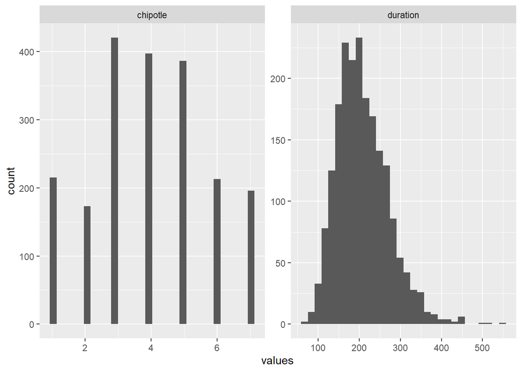

```r
library(caret); library(tidyr)
df %>%
  select(chipotle, duration)%>%
  pivot_longer(1:2, names_to = 'var',values_to = 'values')%>%
  ggplot(aes(x=values))+
  geom_histogram()+
  facet_wrap(~var, scales = 'free')
```

```r
library(e1071)
df %>%
  select(chipotle, duration)%>%
  summarize(skewness_chipotle = skewness(chipotle), skewness_duration = skewness(duration))
```

| skewness_chipotle | skewness_duration |
| --- | --- |
| -0.01208177 | 0.8395247 |

Skewness can be mitigated by applying a suitable functional transformation such as log, square root, or inverse. However, it is hard to know apriori which type of transformation to apply. Another alternative is to empirically identify an appropriate transformation. Box and Cox transformations are a family of transformation that are indexed by a parameter denoted by lambda. Values of lambda reflect many common transformations such as square (lambda = 2), square root (lambda = 0.5), and inverse (lambda = -1).

Here we illustrate the use of the Box Cox transformation. Chipotle had a lambda estimate close to 1, so no transformation was applied. On the other hand, duration had a lambda much different from 1, so a corrective Box-Cox transformation was applied.

```r
library(e1071)
proc = preProcess(df[,c('chipotle','duration')],method = 'BoxCox')
proc$bc # lambda vale to be used in BoxCox transformation
```

```
## $chipotle
## Box-Cox Transformation
##
## 2000 data points used to estimate Lambda
##
## Input data summary:
##    Min. 1st Qu.  Median    Mean 3rd Qu.    Max.
##   1.000   3.000   4.000   3.994   5.000   7.000
##
## Largest/Smallest: 7
## Sample Skewness: -0.0121
##
## Estimated Lambda: 0.9
## With fudge factor, no transformation is applied
##
##
## $duration
## Box-Cox Transformation
##
## 2000 data points used to estimate Lambda
##
## Input data summary:
##    Min. 1st Qu.  Median    Mean 3rd Qu.    Max.
##   71.13  163.24  200.07  208.11  245.99  553.12
##
## Largest/Smallest: 7.78
## Sample Skewness: 0.84
##
## Estimated Lambda: 0.1
## With fudge factor, Lambda = 0 will be used for transformations
```

Here are the histograms after a Box-Cox Transformation.

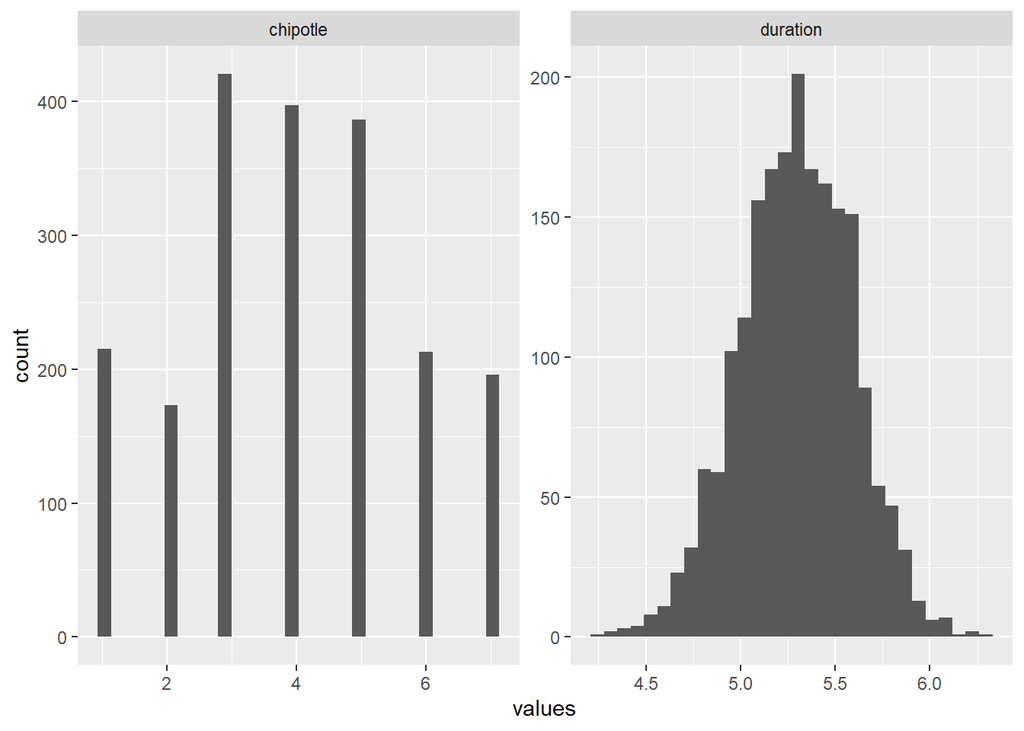

```r
predict(proc, newdata = df)%>%
  select(chipotle, duration)%>%
  pivot_longer(1:2, names_to = 'var',values_to = 'values')%>%
  ggplot(aes(x=values))+
  geom_histogram()+
  facet_wrap(~var, scales = 'free')
```

```r
nearZeroVar(df[,c('health1', 'health2', 'health3', 'mcdonalds', 'chipotle', 'shake_shack' )],saveMetrics = T)
```

|  | freqRatio | percentUnique | zeroVar | nzv |
| --- | --- | --- | --- | --- |
| health1 | 1.013158 | 0.35 | FALSE | FALSE |
| health2 | 2.990268 | 0.35 | FALSE | FALSE |
| health3 | 1.575431 | 0.35 | FALSE | FALSE |
| mcdonalds | 1.023018 | 0.35 | FALSE | FALSE |
| chipotle | 1.057935 | 0.35 | FALSE | FALSE |
| shake_shack | 1.069825 | 0.35 | FALSE | FALSE |

### Combine Variables

In certain situations it makes sense to combine variables to form an index. One such scenario is when survey respondents are asked a multiple questions to measure a single construct. In the fastfood data, respondents were asked three questions to gauge their health consciousness.

Variables may be combined in an unweighted manner by simply averaging their scores. When doing this, care must be taken to ensure the variables are measured on the same scale. Survey researchers average scores so long as the items are rated on the same scale, e.g., 1-7. But, to be sure, one can examine dispersion for the variables to be combined.

Here, we can see the standard deviations of the three health variables are not the same.

```r
apply(X = df[,c('health1', 'health2', 'health3')],
      MARGIN = 2,
      FUN = sd)
```

```
##  health1  health2  health3
## 2.036357 1.075748 1.631677
```

Using `dplyr` verbs

```r
df %>%
  select(health1:health3)%>%
  summarise_all(.funs = sd)
```

| health1 | health2 | health3 |
| --- | --- | --- |
| 2.036357 | 1.075748 | 1.631677 |

```r
df %>%
  select(health1:health3)%>%
  mutate(health1_std = scale(health1), health2_std = scale(health2), health3_std = scale(health3))%>%
  rowwise()%>%
  mutate(health_index = mean(health1_std, health2_std, health3_std, na.rm=T))%>%
  select(health1, health2, health3, health1_std, health2_std, health3_std, health_index)
```

| health1 | health2 | health3 | health1_std | health2_std | health3_std | health_index |
| --- | --- | --- | --- | --- | --- | --- |
| 1 | 1 | 1 | -1.482058483 | -0.6395548 | -0.9382984 | -1.482058483 |
| 6 | 3 | 5 | 0.973306797 | 1.2196160 | 1.5131670 | 0.973306797 |
| 4 | 3 | 4 | -0.008839315 | 1.2196160 | 0.9003007 | -0.008839315 |
| 1 | 1 | 1 | -1.482058483 | -0.6395548 | -0.9382984 | -1.482058483 |
| 1 | 1 | 1 | -1.482058483 | -0.6395548 | -0.9382984 | -1.482058483 |
| 1 | 1 | 1 | -1.482058483 | -0.6395548 | -0.9382984 | -1.482058483 |
| 1 | 1 | 1 | -1.482058483 | -0.6395548 | -0.9382984 | -1.482058483 |
| 3 | 1 | 2 | -0.499912371 | -0.6395548 | -0.3254320 | -0.499912371 |
| 3 | 2 | 3 | -0.499912371 | 0.2900306 | 0.2874343 | -0.499912371 |
| 3 | 3 | 3 | -0.499912371 | 1.2196160 | 0.2874343 | -0.499912371 |

[output cut: 1990 more lines]

If the analyst wants to incorporate the importance of each variable and possesses information about it, variables may be combine in a weighted manner by assigning separate weights to each variable. Finally, certain analytical techniques will automatically determine the weights for combining variables (e.g., principle components analysis).

### Binning

A numeric variable may be grouped into a set of two more discrete bins. This process is known as binning, or categorization or discretization. As an example, change in stock prices is frequently binned into “Up” or “Down”.

In the data, `duration` refers to the time taken to complete the survey. We can bin this variable into preset buckets (e.g., 0, 120, 240, 6000), or use quantiles (e.g., three quantiles, also known as tertiles). Here is an illustration of each of these methods. You will note that we are using `cut` for specifying breaks or buckets and `cut2` from library(Hmisc) for specifying quantiles.

```r
library(Hmisc)
df %>%
  select(duration)%>%
  mutate(preset_bins = cut(df$duration,
                           breaks = c(0,120,240,6000)),
         preset_bins_labels = cut(df$duration,
                           breaks = c(0,120,240,6000),
                           labels =c('Short','Typical','Long')),
         quantile_bins = factor(cut2(duration,
                                     g=3)),
         quantile_bins_labels = factor(cut2(duration,
                                     g=3),
                                labels = c('Short', 'Typical', 'Long')))
```

| duration | preset_bins | preset_bins_labels | quantile_bins | quantile_bins_labels |
| --- | --- | --- | --- | --- |
| 119.33830 | (0,120] | Short | [ 71.1,176) | Short |
| 221.97059 | (120,240] | Typical | [175.9,229) | Typical |
| 260.71333 | (240,6e+03] | Long | [229.4,553] | Long |
| 146.26761 | (120,240] | Typical | [ 71.1,176) | Short |
| 235.98755 | (120,240] | Typical | [229.4,553] | Long |
| 199.90975 | (120,240] | Typical | [175.9,229) | Typical |
| 207.27643 | (120,240] | Typical | [175.9,229) | Typical |
| 195.32862 | (120,240] | Typical | [175.9,229) | Typical |
| 160.70376 | (120,240] | Typical | [ 71.1,176) | Short |
| 123.82832 | (120,240] | Typical | [ 71.1,176) | Short |

[output cut: 1990 more lines]

With preset bins, the number of observations in each bin can be lopsided. On the other hand, when using quantiles, bins are constructed to balance observations.

```r
library(tidyr)
df %>%
  select(duration)%>%
  mutate(preset_bins = cut(df$duration,
                           breaks = c(0,120,240,6000)),
         preset_bins_labels = cut(df$duration,
                           breaks = c(0,120,240,6000),
                           labels =c('Short','Typical','Long')),
         quantile_bins = factor(cut2(duration,
                                     g=3)),
         quantile_bins_labels = factor(cut2(duration,
                                     g=3),
                                labels = c('Short', 'Typical', 'Long')))%>%
  select(preset_bins_labels, quantile_bins_labels)%>%
  pivot_longer(cols = 1:2, names_to = 'var', values_to = 'values')%>%
  group_by(var, values)%>%
  count()%>%
  ungroup()%>%
  pivot_wider(names_from = 1, values_from = n)
```

| values | preset_bins_labels | quantile_bins_labels |
| --- | --- | --- |
| Short | 98 | 667 |
| Typical | 1347 | 667 |
| Long | 555 | 666 |